# batman uscript code

2023-07-31

# 1 Load prereq libraries

```r
library(knitr)
library(phytools)
library(geiger)
library(mice)
library(nlme)  #for gls
```

# 2 Load tree/data and modify

### 2.0.1 Load in the traits and tree.

The data is a combination of data from various sources, such as IUCN, with non-distribute licenses. The data can be freely downloaded and used but not distributed, such as on github.

```r
name.data=read.csv("Bat.Data.Current.csv",stringsAsFactors = T)
  rownames(name.data)=name.data$Species

bat.tree=read.nexus("bigbattree.tre")
```

### 2.0.2 Delete irrelephant stuff 🐘

Delete species from the each of the tree and traits not found in the other

```r
extraSpecies = name.check(bat.tree,name.data)

#delete from tree
bat.tree  = drop.tip(bat.tree,extraSpecies$tree_not_data)

#delete from traits
name.data = name.data[-match(extraSpecies$data_not_tree,name.data$Species),]

name.check(bat.tree,name.data)
```

```
## [1] "OK"
```

### 2.0.3 Rescale variables.

The area being such large numbers overwhelms other smaller numbers in some calculations due to rounding issues, so we convert to `Area.mkm` (area in mega meters or million sq km instead of just Area in sq km.)

```r
name.data=data.frame(name.data,Area.mkm=name.data$Area.km/10^6)
```

### 2.0.4 Capitalize some variables for presentability

```r
levels(name.data$Habitats)[levels(name.data$Habitats)=="Savan"]<-"Savanna"
levels(name.data$Simple.Habitats)[levels(name.data$Simple.Habitats)=="Savan"]<-"Savanna"
name.data$Simple.Primary.diet <-  stringr::str_to_title(name.data$Simple.Primary.diet)
name.data$Primary.diet <- as.factor( stringr::str_to_title(name.data$Primary.diet))
name.data$Island.mainland.classification <-as.factor(  stringr::str_to_title(name.data$Island.mainland.classification))
```

### 2.0.5 Collapse/combine some habitats

```r
table(name.data$Habitats,name.data$Simple.Habitats)
```

```
##
##                          Aquatic Artificial/Terrestrial Caves Forest Open
##   Artificial/Aquatic           3                      0     0      0    0
##   Artificial/Terrestrial       0                    183     0      0    0
##   Caves                        0                      0   129      0    0
##   Desert                       0                      0     0      0    9
##   Forest                       0                      0     0    516    0
##   Grassland                    0                      0     0      0    6
##   Marine                       1                      0     0      0    0
##   Rocky                        0                      0     0      0   26
##   Savanna                      0                      0     0      0    0
##   Shrubland                    0                      0     0      0   46
##   Unknown                      0                      0     0      0    0
##   Wetlands                    12                      0     0      0    0
##
##                          Savanna
##   Artificial/Aquatic           0
##   Artificial/Terrestrial       0
##   Caves                        0
##   Desert                       0
##   Forest                       0
##   Grassland                    0
##   Marine                       0
##   Rocky                        0
##   Savanna                     64
##   Shrubland                    0
##   Unknown                      0
##   Wetlands                     0
```

In Habitat, some variables have low numbers below 10 (arbitrary threshold), so we’ll group them together so that standard errors are reasonably estimated.

```r
collapsed.Habitats = as.character(name.data$Habitats)
collapsed.Habitats[collapsed.Habitats=="Unknown"]=NA

aquatic = match(collapsed.Habitats,c("Artificial/Aquatic","Marine","Wetlands"))
collapsed.Habitats[!is.na(aquatic)]="Aquatic"

otheropen = match(collapsed.Habitats,c("Desert","Grassland"))
collapsed.Habitats[!is.na(otheropen)]="OtherOpen"


name.data=data.frame(name.data,collapsed.Habitats=as.factor(collapsed.Habitats))
name.data=data.frame(name.data,X.centroid.abs=abs(name.data$X.centroid))
```

```r
table(name.data$Habitats,collapsed.Habitats)
```

```
##                         collapsed.Habitats
##                          Aquatic Artificial/Terrestrial Caves Forest OtherOpen
##   Artificial/Aquatic           3                      0     0      0         0
##   Artificial/Terrestrial       0                    183     0      0         0
##   Caves                        0                      0   129      0         0
##   Desert                       0                      0     0      0         9
##   Forest                       0                      0     0    516         0
##   Grassland                    0                      0     0      0         6
##   Marine                       1                      0     0      0         0
##   Rocky                        0                      0     0      0         0
##   Savanna                      0                      0     0      0         0
##   Shrubland                    0                      0     0      0         0
##   Unknown                      0                      0     0      0         0
##   Wetlands                    12                      0     0      0         0
##                         collapsed.Habitats
##                          Rocky Savanna Shrubland
##   Artificial/Aquatic         0       0         0
##   Artificial/Terrestrial     0       0         0
##   Caves                      0       0         0
##   Desert                     0       0         0
##   Forest                     0       0         0
##   Grassland                  0       0         0
##   Marine                     0       0         0
##   Rocky                     26       0         0
##   Savanna                    0      64         0
##   Shrubland                  0       0        46
##   Unknown                    0       0         0
##   Wetlands                   0       0         0
```

### 2.0.6 Transform altidude

Next, I’m going to transform the altitudinal data. We initially found the max/min values had opposite signs and it could be having wider/narrower altitude bands was really at work so instead of max/min, we create a location (middle point of altitude) and range (from the middle) variable.

```r
Altitude.mid.m = with(name.data,(Altitudil.range.upper.m+Altitudil.range.lower.m)/2)
Altitude.range.m = with(name.data,Altitudil.range.upper.m-Altitudil.range.lower.m)

name.data=data.frame(name.data,Altitude.mid.m,Altitude.range.m)
```

### 2.0.7 Choose between collinear variables

```r
varsToUse = c(
  "Conservation.category.numeric",
  "collapsed.Habitats",
  "Altitude.mid.m","Altitude.range.m",
  "Forearm.avg.mm","Head.body.avg.mm","Y.centroid.abs",
  "Temp.annual.range",
  "Temp.seasonality","Max.temp.warmest.month","Isothermality",
  "Simple.Primary.diet",#"Primary.diet" ,
  "weight.avg.g" ,
  "Island.mainland.classification" ,
  "Min.temp.coldest.month" ,
  "Annual.precip." ,
  "Area.mkm"  #rather than Area.km
)
sort(names(name.data));varsToUse[is.na(match(varsToUse,names(name.data)))]
 modelVariables = name.data[,varsToUse]

Species = rownames(modelVariables)

(propmissing=apply(modelVariables,2,is.na) |> colMeans())
```

- **weight.avg.g**
- Forearm.avg.mm
- Head.body.avg.mm.

Similarly, a variety of the temperature variables are highly correlated so we’ll just keep Max.temp.warmest.month.

- **Max.temp.warmest.month**
- Temp.seasonality
- Y.centroid.abs
- Temp.annual.range
- Isothermality
- Min.temp.coldest.month

```r
colsToRemove = c("Forearm.avg.mm","Head.body.avg.mm",
                 "Y.centroid.abs",
                 "Temp.seasonality",
                 "Isothermality",
                 "Temp.annual.range",
                 "Min.temp.coldest.month"
                 #"Max.temp.warmest.month"
                 )
indicesOfColsToremove = match(colsToRemove,names(modelVariables))
  modelVariables = modelVariables[,-indicesOfColsToremove]
```

# 3 Impute missing data

We only need to impute the variables that have a proportion of missing that’s greater than zero. The default method is Predictive Mean Matching (PMM) which is hot-deck imputation or like a nearest neighbour approach. For every value we’re missing, some “similar” observation’s corresponding value is used. Note: it specifically does not always take the most similar (but more similar ones are more likely to be selected). That way, if when we impute many times, we do actually obtain a variety of values, with more sensible ones more often, so we get some randomness. This will be our way of introducing variability due to missingness (in addition to usual variability due to randomness we base p-values and such off of).

```r
nimp = 20        #number of imputations/complete datasets to create
set.seed(2022)   #so that if we rerun this we get the same datasets


missingResp = is.na(name.data$Conservation.category.numeric)

cltype = ifelse(Sys.info()["sysname"]=="Windows","PSOCK","FORK")
traits.mice.abstract = parlmice(data = modelVariables, m = nimp,ncore=parallel::detectCores(),cl.type = cltype)
#traits.mice.abstract = mice(data = modelVariables, m = nimp)
traits.mice.abstract$loggedEvents
new.traits.list = complete(traits.mice.abstract,action="all")
new.traits.list.complete = lapply(new.traits.list,function(ntl)ntl[!missingResp,])
```

The `loggedEvents` line is to see what the warnings are. In our case, I think it means the that habitat is almost constant and taken out of imputation for the corresponding dep variables. You can view it by the line `traits.mice.abstract$loggedEvents` (not shown).

# 4 Create Models

```r
#Create a helper function that makes a single gls model for a given complete data set

fitFullModel.collapsedhabitats = function(new.traits.i){
  Species = rownames(new.traits.i)
  new.traits.i=data.frame(Species=rownames(new.traits.i),new.traits.i)
  Full.Models <-gls(Conservation.category.numeric~ . -Species,data = new.traits.i,
                    correlation = corBrownian(phy = bat.tree,form=~Species),
                    method = "ML")
}



#
#
#
#
#
# fitFullModel.simplehabitats = function(new.traits.i){
#   Species = rownames(new.traits.i)
#   new.traits.i=data.frame(Species=rownames(new.traits.i),new.traits.i)
#   Full.Models <-gls(Conservation.category.numeric~
#                       Simple.Habitats +
#                       Simple.Primary.diet +
#                       weight.avg.g +
#                       Island.mainland.classification +
#                       Min.temp.coldest.month +
#                       Annual.precip. +
#                       Area.mkm,
#                     correlation = corBrownian(phy = bat.tree,form=~Species),
#                     data = new.traits.i,
#                     method = "ML")
# }
# fitFullModel.habitats = function(new.traits.i){
#   Species = rownames(new.traits.i)
#   new.traits.i=data.frame(Species=rownames(new.traits.i),new.traits.i)
#   Full.Models <-gls(Conservation.category.numeric~.,
#                     correlation = corBrownian(phy = bat.tree,form=~Species),
#                     data = new.traits.i,
#                     method = "ML")
#
#}
```

To parallelize the code, we can use the following lines. Note, the first line (not run) is short but only works on mac/linux. The second chunk works on all operating systems.

```r
#this line should be parallelized if you can.
#e.g., on linux/mac you can use forking (takes same amt of time, just fewer lines of code)
#     library(parallel)
#     imputedModelsGLS = mclapply(new.traits.list,fitFullModel,mc.cores=detectCores())
```

```r
#code for windows  parallelization (works on mac/linux too)
library(parallel)
mclapp=function(X,FUN,...)parallel::mclapply(X,FUN,mc.cores=parallel::detectCores(),...)
mcsapp=function(X,FUN,...)simplify2array(mclapp(X,FUN,...))

cl=makePSOCKcluster(detectCores())
clusterExport(cl,varlist=c("bat.tree"))
clusterEvalQ(cl,c(
  library(ape),
  library(nlme)
  )
)
imputedModelsGLS          = parLapplyLB(cl = cl, fun=fitFullModel.collapsedhabitats, X=new.traits.list )
imputedModelsGLS.complete = parLapplyLB(cl = cl, fun=fitFullModel.collapsedhabitats, X=new.traits.list.complete)

stopCluster(cl)
```

# 5 Analysis

### 5.0.1 Helper variables used in analysis

```r
imputedGLS.residuals = sapply(imputedModelsGLS, function(mod)mod$residuals)
imputedGLS.fitted    = sapply(imputedModelsGLS, function(mod)mod$fitted)

averagePredictedStatus.imputedgls = rowMeans(imputedGLS.fitted)

actualStatus = name.data$Conservation.category.numeric
knownSpecies = !is.na(actualStatus)
completeCases = complete.cases(name.data)

 knownPredictedStatuses=   data.frame(
   actual    =actualStatus[knownSpecies],
   predicted =averagePredictedStatus.imputedgls[knownSpecies],mod="gls",dataset="imputed"
  )

knownPredictedStatuses$actual=as.factor(knownPredictedStatuses$actual)
```

## 5.1 Boxplots of fitted/actual

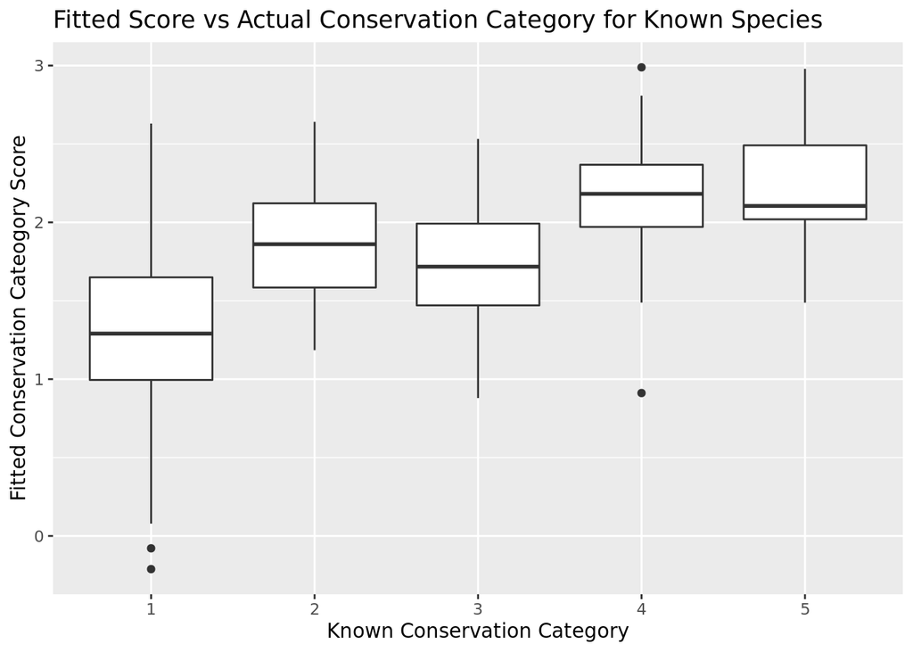

```r
library(ggplot2)
ggplot(knownPredictedStatuses,aes(x=actual,y=predicted))+
  geom_boxplot(data = knownPredictedStatuses)+
    xlab("Known Conservation Category")+
  ylab("Fitted Conservation Cateogory Score")+
  ggtitle("Fitted Score vs Actual Conservation Category for Known Species")
```

# 6 Comparison of the highest risk species (point estimates)

```r
allscores = data.frame(
  actual=name.data$Conservation.category.numeric,
  medianimputedGLS=apply(imputedGLS.fitted,1,median)
)

ord = order(allscores$medianimputedGLS,decreasing=T)

topEstimates = (allscores[ord,])
head(topEstimates,20)
```

```
##                        actual medianimputedGLS
## Rhinolophus_willardi        4         2.988662
## Phyllonycteris_aphylla      5         2.979376
## Rhinolophus_hilli           5         2.809707
## Pteropus_aldabrensis        4         2.807604
## Pteralopex_flanneryi        5         2.682556
## Rousettus_linduensis       NA         2.680245
## Pteropus_melanopogon        4         2.661550
## Chaerephon_solomonis        4         2.659499
## Pteropus_voeltzkowi         2         2.641080
## Pteropus_niger              4         2.636590
## Plecotus_sacrimontis        1         2.630227
## Nyctophilus_microdon       NA         2.627018
## Carollia_manu               1         2.621437
## Pteropus_livingstonii       5         2.620664
## Pteronotus_quadridens       1         2.612822
## Nyctimene_minutus           2         2.609886
## Falsistrellus_mordax       NA         2.605978
## Hipposideros_demissus       4         2.578995
## Hipposideros_papua          1         2.577967
## Rhinolophus_mabuensis       4         2.574071
```

## 6.1 Boxplots of highest GLS estimates (for missing Status)

```r
require(reshape2)
```

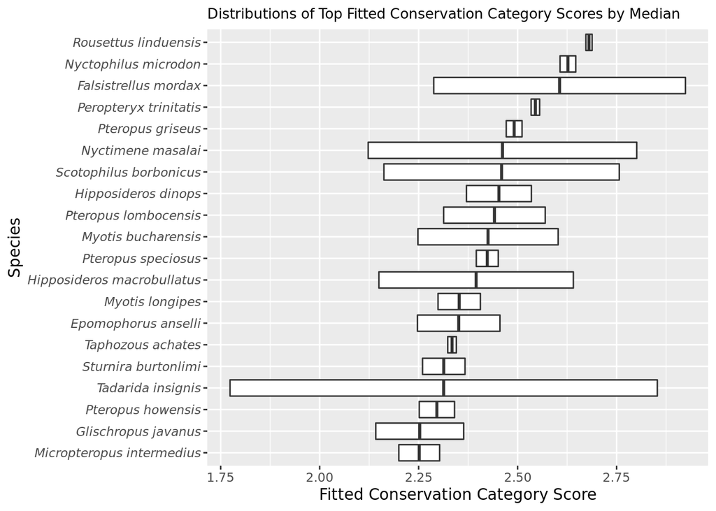

```r
top=1:20

missing = is.na(allscores$actual)

missingScores = allscores[missing,]
missingImputedGLS.fitted = imputedGLS.fitted[missing,]




ord = order(missingScores$medianimputedGLS,decreasing=T)
topEstimates = (missingScores[ord,])
ordtop = rev(ord[top])

imputeddf = melt(missingImputedGLS.fitted[ordtop,],varnames=c("Species","dataset"))
imputeddf[,2]="imputedgls"

imputeddf$dataset=as.factor(imputeddf$dataset)


spacedSpecies = sapply(strsplit(as.character(imputeddf$Species),"_"),paste,collapse=" ")
imputeddf=data.frame(imputeddf,spacedSpecies=spacedSpecies)

#head(imputeddf)

ggplot(imputeddf,aes(x=reorder(spacedSpecies,value,FUN=median),y=value))+
  geom_boxplot()+
  ylab("Fitted Conservation Category Score")+ggtitle("Distributions of Top Fitted Conservation Category Scores by Median")+theme(plot.title = element_text(size = 10))+xlab("Species")+
  theme(axis.text.y = element_text(face = "italic"))+
  coord_flip()
```

# 7 Conservation Category Scores by species

```r
imputedEstimates=data.frame(
  glsestimate=rowMeans(imputedGLS.fitted),
  actual = as.factor(name.data$Conservation.category.numeric),
  row.names=Species)

## habitat, diet, island mainland, imn temp coldest month, area.
ordofvars = match(row.names(imputedEstimates),rownames(modelVariables))
head(ordofvars)
```

```
## [1] 1 2 3 4 5 6
```

```r
imputedEstimates2 = data.frame(imputedEstimates,modelVariables[ordofvars,])
```

### 7.0.1 Highest Scores

```r
imputedEstimates2[order(imputedEstimates2$glsestimate,decreasing=T)[1:40],]
```

```
##                           glsestimate actual Conservation.category.numeric
## Rhinolophus_willardi         2.988662      4                             4
## Phyllonycteris_aphylla       2.979376      5                             5
## Rhinolophus_hilli            2.809707      5                             5
## Pteropus_aldabrensis         2.807604      4                             4
## Pteralopex_flanneryi         2.682556      5                             5
## Rousettus_linduensis         2.680245   <NA>                            NA
## Pteropus_melanopogon         2.661550      4                             4
## Chaerephon_solomonis         2.659499      4                             4
## Pteropus_voeltzkowi          2.641080      2                             2
## Pteropus_niger               2.636590      4                             4
## Plecotus_sacrimontis         2.630227      1                             1
## Nyctophilus_microdon         2.627018   <NA>                            NA
## Carollia_manu                2.621437      1                             1
## Pteropus_livingstonii        2.620664      5                             5
## Pteronotus_quadridens        2.612822      1                             1
## Nyctimene_minutus            2.609886      2                             2
## Falsistrellus_mordax         2.605978   <NA>                            NA
## Hipposideros_demissus        2.578995      4                             4
## Hipposideros_papua           2.577967      1                             1
## Rhinolophus_mabuensis        2.574071      4                             4
## Pteropus_mariannus           2.565572      4                             4
## Pteropus_conspicillatus      2.565176      1                             1
## Peropteryx_trinitatis        2.544832   <NA>                            NA
## Dyacopterus_rickarti         2.543143      4                             4
## Hipposideros_sumbae          2.542726      1                             1
## Alionycteris_paucidentata    2.536112      1                             1
## Nycticeius_cubanus           2.532235      3                             3
## Notopteris_neocaledonica     2.522934      4                             4
## Chaerephon_bregullae         2.511658      4                             4
## Pteropus_dasymallus          2.496898      2                             2
## Hipposideros_calcaratus      2.491686      1                             1
## Pteropus_griseus             2.491209   <NA>                            NA
## Acerodon_jubatus             2.490907      4                             4
## Pteropus_rufus               2.485969      2                             2
## Nycteris_javanica            2.482484      2                             2
## Pteropus_rodricensis         2.477617      4                             4
## Emballonura_serii            2.473573      2                             2
## Nyctiellus_lepidus           2.468220      1                             1
## Dobsonia_pannietensis        2.465998      3                             3
```

[output cut: 150 more lines]

```
## Alionycteris_paucidentata           2596 6.417883e-03
## Nycticeius_cubanus                  1350 2.918345e-02
## Notopteris_neocaledonica            1634 1.254124e-03
## Chaerephon_bregullae                  NA 2.061322e-02
## Pteropus_dasymallus                   NA 2.890669e-03
## Hipposideros_calcaratus               NA 2.174792e-01
## Pteropus_griseus                    2252 2.221328e-01
## Acerodon_jubatus                    2603 1.444986e-01
## Pteropus_rufus                      1448 1.853892e-01
## Nycteris_javanica                   2189 1.354811e-01
## Pteropus_rodricensis                1083 1.109314e-04
## Emballonura_serii                     NA 1.149734e-02
## Nyctiellus_lepidus                  1144 1.101841e-01
## Dobsonia_pannietensis                 NA 5.415202e-03
## Rhinolophus_hillorum                1256 2.657789e-02
```

### 7.0.2 Lowest Scores

```r
imputedEstimates2[order(imputedEstimates2$glsestimate,decreasing=F)[1:40],]
```

```
##                           glsestimate actual Conservation.category.numeric
## Desmodus_rotundus         -0.21164353      1                             1
## Phyllostomus_discolor     -0.07880272      1                             1
## Eumops_perotis             0.07854037      1                             1
## Eptesicus_brasiliensis     0.09737607      1                             1
## Nyctinomops_macrotis       0.12295102      1                             1
## Rhinolophus_ferrumequinum  0.15808380      1                             1
## Molossus_molossus          0.17401377      1                             1
## Eptesicus_fuscus           0.17690036      1                             1
## Myotis_nigricans           0.19044112      1                             1
## Vespertilio_murinus        0.21889540      1                             1
## Myotis_daubentonii         0.23430894      1                             1
## Lasiurus_blossevillii      0.24086436      1                             1
## Cynomops_planirostris      0.29821567      1                             1
## Nyctinomops_aurispinosus   0.35559886      1                             1
## Myotis_riparius            0.36950171      1                             1
## Micronycteris_minuta       0.38674612      1                             1
## Artibeus_lituratus         0.39492780      1                             1
## Myotis_volans              0.39600062      1                             1
## Nycteris_macrotis          0.39636525      1                             1
## Lasiurus_ega               0.40469394      1                             1
## Myotis_muricola            0.40623825      1                             1
## Eumops_auripendulus        0.40696526      1                             1
## Lasiurus_cinereus          0.41895931      1                             1
## Anoura_latidens            0.42772742      1                             1
## Macrophyllum_macrophyllum  0.44104004      1                             1
## Uroderma_magnirostrum      0.44629327      1                             1
## Eptesicus_andinus          0.46513317      1                             1
## Lonchophylla_thomasi       0.49191109      1                             1
## Diclidurus_albus           0.49216495      1                             1
## Hipposideros_ruber         0.49324229      1                             1
## Nycteris_hispida           0.50126330      1                             1
## Pipistrellus_tenuis        0.50941150      1                             1
## Pipistrellus_kuhlii        0.51262161      1                             1
## Carollia_perspicillata     0.51715899      1                             1
## Myotis_albescens           0.51921684      1                             1
## Lionycteris_spurrelli      0.52697977      1                             1
## Eptesicus_nilssonii        0.52886474      1                             1
## Molossus_rufus             0.53144051      1                             1
## Rhinolophus_pearsonii      0.53417380      1                             1
```

[output cut: 191 more lines]

```
## Uroderma_magnirostrum     10.8309485
## Eptesicus_andinus          0.8112928
## Lonchophylla_thomasi       8.3830716
## Diclidurus_albus          12.4967275
## Hipposideros_ruber         9.0601415
## Nycteris_hispida          11.5052783
## Pipistrellus_tenuis        7.8483224
## Pipistrellus_kuhlii       10.9059603
## Carollia_perspicillata    13.7958916
## Myotis_albescens          14.5947068
## Lionycteris_spurrelli      7.2741477
## Eptesicus_nilssonii       10.4724306
## Molossus_rufus            14.7994903
## Rhinolophus_pearsonii      3.1763193
## Nyctinomops_laticaudatus  13.1007552
```

# 8 Summary info about missing data

```r
propmissing=apply(modelVariables,2,is.na) |> colMeans()
kable(as.data.frame(propmissing))
```

|  | propmissing |
| --- | --- |
| Conservation.category.numeric | 0.1594621 |
| collapsed.Habitats | 0.0441883 |
| Altitude.mid.m | 0.4409222 |
| Altitude.range.m | 0.4409222 |
| Max.temp.warmest.month | 0.1181556 |
| Simple.Primary.diet | 0.0000000 |
| weight.avg.g | 0.1277618 |
| Island.mainland.classification | 0.0288184 |
| Annual.precip. | 0.1181556 |
| Area.mkm | 0.0000000 |

```r
missingPredictors = !complete.cases(modelVariables[,-1])
missingResponse   = modelVariables[,1] |> is.na()

(missingTable = table(missingPredictors,missingResponse)/length(missingPredictors)|> round(2))
```

```
##                  missingResponse
## missingPredictors      FALSE       TRUE
##             FALSE 0.38136407 0.03746398
##             TRUE  0.45917387 0.12199808
```

```r
incompletePredictors = missingTable[2,]|>sum()|> (`*`)(100)|>round(2)
incompleteTotally = (1-missingTable[1,1])|>(`*`)(100)|>round(2)
```

58.12% of the predictor data contains at least one missing value and 61.86% of the species information (predictor data and conservation status) contains at least one missing value.

# 9 Model variables

The summary of the model estimates (not including the standard errors) are shown below are shown below.

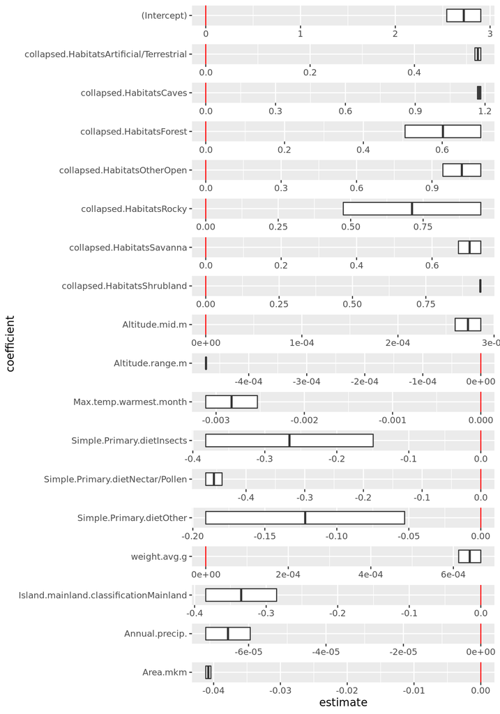

```r
summaries = lapply(imputedModelsGLS,summary)

allEstimates = sapply(summaries,function(s) s$coefficients)

#put all the estimates into a dataframe
estimatesdf = reshape2::melt(allEstimates,value.name = c("estimate"),varnames=c("coefficient","imputationNumber"))

ggplot(estimatesdf,aes(x=coefficient,y=estimate))+
  geom_boxplot()+geom_hline(yintercept=0,color="red")+
  facet_wrap(coefficient~.,scales="free",ncol=1)+
   theme(strip.text.x = element_blank())+coord_flip()
```

# 10 Frequentist summary tables

Manually calculate the standard errors and make confidence intervals and pvalues

```r
avgEstimate = data.frame(avgEstimate=apply(allEstimates,1,mean))

ttables = lapply(summaries,function(i)i$tTable)

stdErrs = sapply(ttables,function(i)i[,2])

#pool the standard error estimates
avgstderr = rowMeans(stdErrs)
vw = rowMeans(stdErrs^2)  #variance within
vb=  apply(stdErrs,1,var) #variance betwn (sample var)
vtot = vw+(1+1/(nimp))*vb
stdpooled = sqrt(vtot)

avgEstimate=apply(allEstimates,1,mean)

#for  α=.05 find the bounds (lb,ub) and then the teststat-> pvalue
siglevel = 0.05; crit = -qnorm(siglevel/2)

lb = avgEstimate - crit*stdpooled
ub = avgEstimate + crit*stdpooled

teststat = avgEstimate/stdpooled
pval = 2*pnorm(-abs(teststat))

flags = c("****", "***", "**", "*", "")[findInterval(pval,c(0, 0.0001, 0.001, 0.01, 0.05, 1))]
#(nothing has been printed yet)
```

## 10.1 for slopes and significance

```r
#print the pvalues for the estimates in a nice table for html
kable(data.frame(avgEstimate,stdpooled,pval,flags))
```

|  | avgEstimate | stdpooled | pval | flags |
| --- | --- | --- | --- | --- |
| (Intercept) | 2.7226171 | 1.5799106 | 0.0848392 |  |
| collapsed.HabitatsArtificial/Terrestrial | 0.5215825 | 0.3145923 | 0.0973249 |  |
| collapsed.HabitatsCaves | 1.1747266 | 0.3195349 | 0.0002366 | *** |
| collapsed.HabitatsForest | 0.6018440 | 0.3101793 | 0.0523420 |  |
| collapsed.HabitatsOtherOpen | 1.0189686 | 0.4148930 | 0.0140501 | * |
| collapsed.HabitatsRocky | 0.7118197 | 0.3599383 | 0.0479720 | * |
| collapsed.HabitatsSavanna | 0.6996690 | 0.3297065 | 0.0338296 | * |
| collapsed.HabitatsShrubland | 0.9357881 | 0.3405348 | 0.0059961 | ** |
| Altitude.mid.m | 0.0002729 | 0.0000830 | 0.0010148 | ** |
| Altitude.range.m | -0.0004736 | 0.0000517 | 0.0000000 | **** |
| Max.temp.warmest.month | -0.0028243 | 0.0007877 | 0.0003362 | *** |
| Simple.Primary.dietInsects | -0.2657681 | 0.5195887 | 0.6090030 |  |
| Simple.Primary.dietNectar/Pollen | -0.4547415 | 0.2391953 | 0.0572849 |  |
| Simple.Primary.dietOther | -0.1219664 | 0.4292751 | 0.7763170 |  |
| weight.avg.g | 0.0006396 | 0.0002628 | 0.0149157 | * |
| Island.mainland.classificationMainland | -0.3348845 | 0.0938315 | 0.0003583 | *** |
| Annual.precip. | -0.0000653 | 0.0000338 | 0.0533776 |  |
| Area.mkm | -0.0407941 | 0.0102816 | 0.0000726 | **** |

## 10.2 for intervals

```r
#print the conf intervals for the estimates in a nice table for html
sig = (sign(lb)==sign(ub))|>ifelse(" *","")
kable(data.frame(estimate=avgEstimate,lb,ub,sig ))
```

|  | estimate | lb | ub | sig |
| --- | --- | --- | --- | --- |
| (Intercept) | 2.7226171 | -0.3739508 | 5.8191850 |  |
| collapsed.HabitatsArtificial/Terrestrial | 0.5215825 | -0.0950071 | 1.1381721 |  |
| collapsed.HabitatsCaves | 1.1747266 | 0.5484497 | 1.8010035 | * |
| collapsed.HabitatsForest | 0.6018440 | -0.0060962 | 1.2097842 |  |
| collapsed.HabitatsOtherOpen | 1.0189686 | 0.2057932 | 1.8321440 | * |
| collapsed.HabitatsRocky | 0.7118197 | 0.0063537 | 1.4172858 | * |
| collapsed.HabitatsSavanna | 0.6996690 | 0.0534562 | 1.3458818 | * |
| collapsed.HabitatsShrubland | 0.9357881 | 0.2683522 | 1.6032240 | * |
| Altitude.mid.m | 0.0002729 | 0.0001101 | 0.0004356 | * |
| Altitude.range.m | -0.0004736 | -0.0005750 | -0.0003723 | * |
| Max.temp.warmest.month | -0.0028243 | -0.0043681 | -0.0012805 | * |
| Simple.Primary.dietInsects | -0.2657681 | -1.2841433 | 0.7526071 |  |
| Simple.Primary.dietNectar/Pollen | -0.4547415 | -0.9235558 | 0.0140727 |  |
| Simple.Primary.dietOther | -0.1219664 | -0.9633301 | 0.7193973 |  |
| weight.avg.g | 0.0006396 | 0.0001247 | 0.0011546 | * |
| Island.mainland.classificationMainland | -0.3348845 | -0.5187908 | -0.1509782 | * |
| Annual.precip. | -0.0000653 | -0.0001316 | 0.0000010 |  |
| Area.mkm | -0.0407941 | -0.0609457 | -0.0206426 | * |

## 10.3 Note about the reference variable

The significance of the slopes are all with respect to the **reference** variables.

- Habitat: Aquatic
- Diet: Fruit

If a diet slope is positive, that means that diet **increases the conservation score compared to a Fruit-eater**.

If a habitat slope is negative, that means it **decreases the conservation score compared to Aquatic**.

# 11 Visual summaries

Looking at the visual summaries, it’s not surprising that only the variables with variability in score come up significant.

## 11.1 Category by Habitat

```r
subsettable = with(modelVariables,data.frame(collapsed.Habitats,Conservation.category.numeric))
subsettable=subsettable[complete.cases(subsettable),]
tab = addmargins(table(subsettable))

kable(tab)
```

|  | 1 | 2 | 3 | 4 | 5 | Sum |
| --- | --- | --- | --- | --- | --- | --- |
| Aquatic | 12 | 1 | 0 | 0 | 0 | 13 |
| Artificial/Terrestrial | 130 | 16 | 15 | 9 | 2 | 172 |
| Caves | 73 | 8 | 11 | 19 | 3 | 114 |
| Forest | 300 | 55 | 40 | 26 | 10 | 431 |
| OtherOpen | 11 | 0 | 0 | 3 | 0 | 14 |
| Rocky | 19 | 1 | 3 | 2 | 0 | 25 |
| Savanna | 47 | 0 | 1 | 3 | 0 | 51 |
| Shrubland | 35 | 4 | 2 | 3 | 0 | 44 |
| Sum | 627 | 85 | 72 | 65 | 15 | 864 |

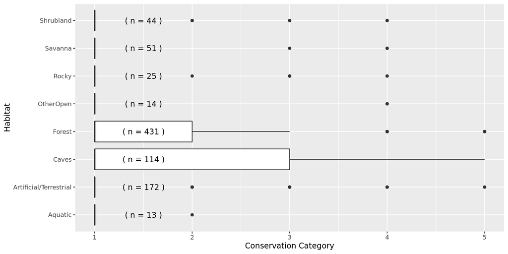

```r
p=nrow(tab)-1
habitats = rownames(tab);habitats=habitats[1:p]#removes "sum"
sizes = paste( "( n =",tab[1:p,ncol(tab)],")")

size.df = data.frame(
  sizes=sizes,
  x=seq_len(p),
  y=rep(1.5,p)
)


ggplot(subsettable,aes(x=collapsed.Habitats,y=Conservation.category.numeric))+
  geom_boxplot()+xlab("Habitat")+ylab("Conservation Category")+
  geom_text(data=size.df,aes(label=sizes,y=y,x=x))+
  coord_flip()
```

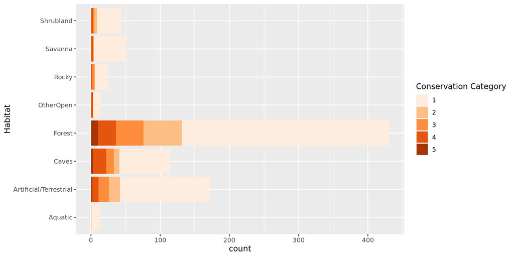

```r
#boxplot(modelVariables$Conservation.category.numeric~modelVariables$Habitats)

ggplot(subsettable,aes(x=collapsed.Habitats))+
  geom_bar(aes(fill=factor(Conservation.category.numeric)))+
  labs(fill="Conservation Category")+
  scale_fill_brewer(palette=7)+
  xlab("Habitat")+
  coord_flip()
```

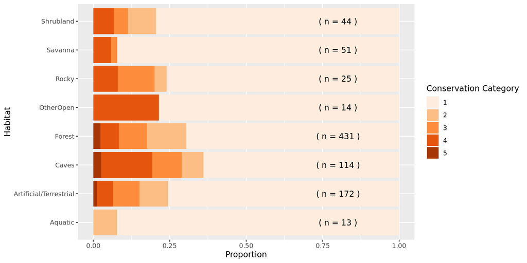

```r
size.df$x = habitats
size.df$y=0.8

ggplot(subsettable,aes(x=collapsed.Habitats))+
  geom_bar(aes(fill=factor(Conservation.category.numeric)),position="fill")+
  scale_fill_brewer(palette=7)+xlab("Habitat")+ylab("Known Conservation Category")+
  labs(fill="Conservation Category")+
  ylab("Proportion")+
  xlab("Habitat")+
  geom_text(data=size.df,aes(label=sizes,y=y,x=x))+
  coord_flip()
```

## 11.2 Category by Diet

```r
subsettable = with(modelVariables,data.frame(Simple.Primary.diet,Conservation.category.numeric))
subsettable=subsettable[complete.cases(subsettable),]
tab = addmargins(table(subsettable))

kable(tab)
```

|  | 1 | 2 | 3 | 4 | 5 | Sum |
| --- | --- | --- | --- | --- | --- | --- |
| Fruit | 126 | 30 | 17 | 23 | 8 | 204 |
| Insects | 451 | 48 | 51 | 40 | 8 | 598 |
| Nectar/Pollen | 37 | 4 | 5 | 4 | 0 | 50 |
| Other | 16 | 3 | 2 | 2 | 0 | 23 |
| Sum | 630 | 85 | 75 | 69 | 16 | 875 |

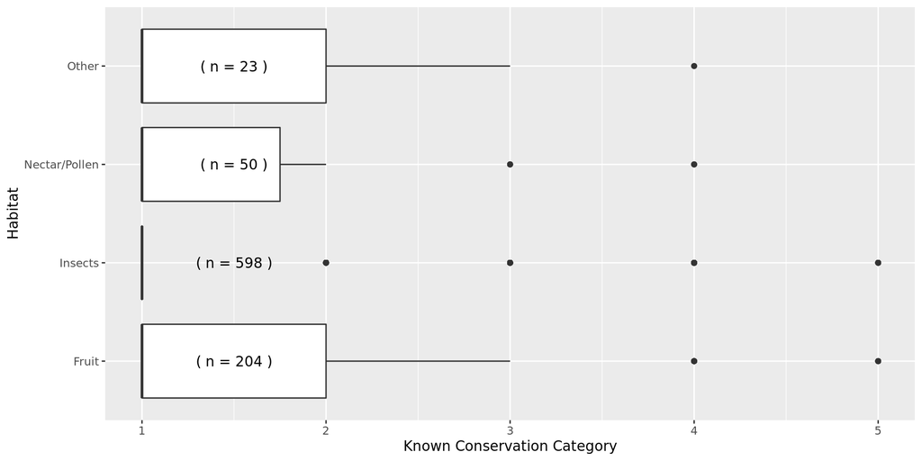

```r
p=nrow(tab)-1
diets = rownames(tab);diets=diets[1:p]#removes "sum"
sizes = paste( "( n =",tab[1:p,ncol(tab)],")")

size.df = data.frame(
  sizes=sizes,
  x=seq_len(p),
  y=rep(1.5,p)
)


ggplot(subsettable,aes(x=Simple.Primary.diet,y=Conservation.category.numeric))+
  geom_boxplot()+xlab("Habitat")+ylab("Known Conservation Category")+
  geom_text(data=size.df,aes(label=sizes,y=y,x=x))+
  coord_flip()
```

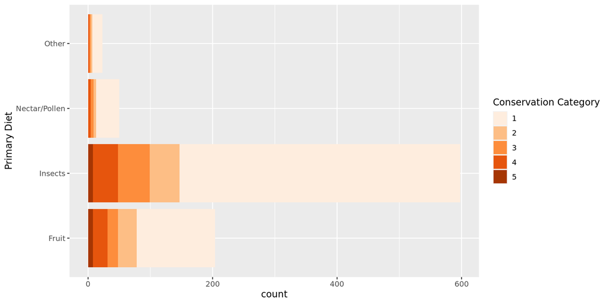

```r
#boxplot(modelVariables$Conservation.category.numeric~modelVariables$Habitats)

ggplot(subsettable,aes(x=Simple.Primary.diet))+
  geom_bar(aes(fill=factor(Conservation.category.numeric)))+
  scale_fill_brewer(palette=7)+
  labs(fill="Conservation Category")+
  xlab("Primary Diet")+
  coord_flip()
```

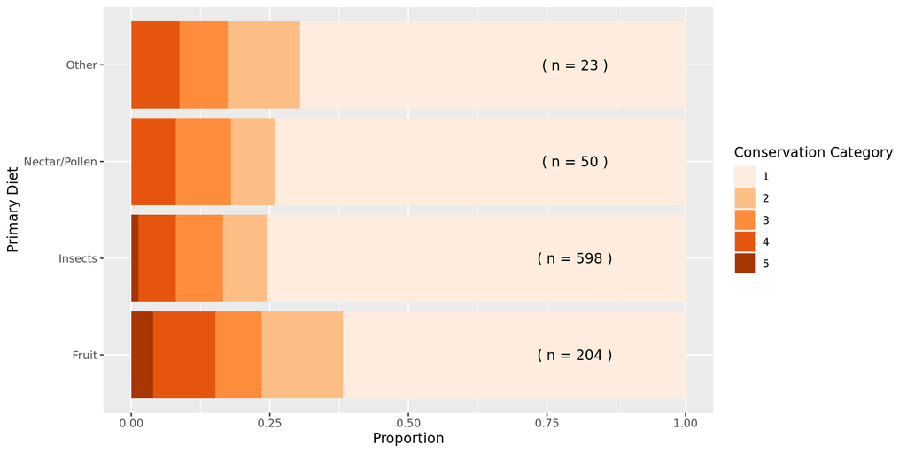

```r
size.df$x = diets
size.df$y=0.8

ggplot(subsettable,aes(x=Simple.Primary.diet))+
  geom_bar(aes(fill=factor(Conservation.category.numeric)),position="fill")+
  scale_fill_brewer(palette=7)+
  ylab("Proportion")+
  xlab("Primary Diet")+
  geom_text(data=size.df,aes(label=sizes,y=y,x=x))+
  labs(fill="Conservation Category")+
  coord_flip()
```

## 11.3 Category by Island/mainland

```r
subsettable = with(modelVariables,data.frame(Island.mainland.classification,Conservation.category.numeric))
subsettable=subsettable[complete.cases(subsettable),]
tab = addmargins(table(subsettable))

kable(tab)
```

|  | 1 | 2 | 3 | 4 | 5 | Sum |
| --- | --- | --- | --- | --- | --- | --- |
| Island | 146 | 54 | 33 | 41 | 12 | 286 |
| Mainland | 463 | 31 | 37 | 26 | 3 | 560 |
| Sum | 609 | 85 | 70 | 67 | 15 | 846 |

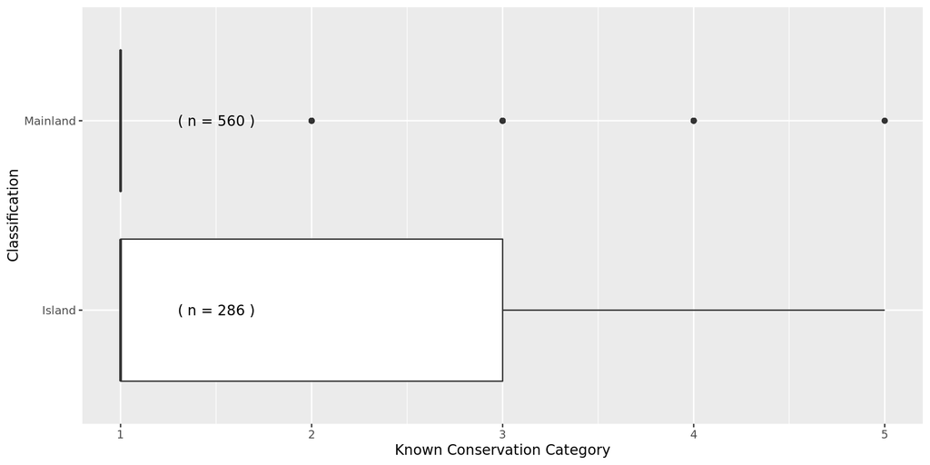

```r
p=nrow(tab)-1
classification = rownames(tab);classification=classification[1:p]#removes "sum"
sizes = paste( "( n =",tab[1:p,ncol(tab)],")")

size.df = data.frame(
  sizes=sizes,
  x=seq_len(p),
  y=rep(1.5,p)
)


ggplot(subsettable,aes(x=Island.mainland.classification,y=Conservation.category.numeric))+
  geom_boxplot()+xlab("Classification")+ylab("Known Conservation Category")+
  geom_text(data=size.df,aes(label=sizes,y=y,x=x))+
  coord_flip()
```

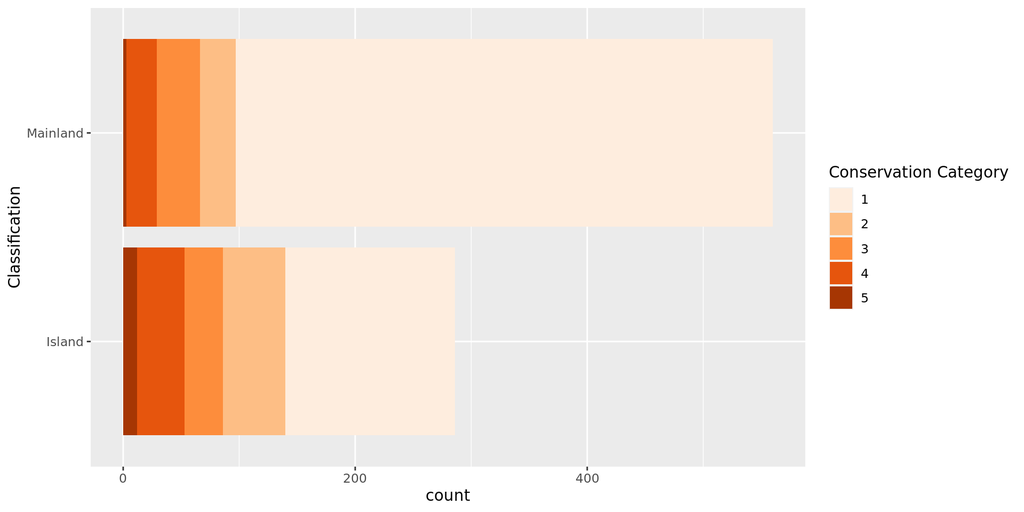

```r
#boxplot(modelVariables$Conservation.category.numeric~modelVariables$Habitats)

ggplot(subsettable,aes(x=Island.mainland.classification))+
  geom_bar(aes(fill=factor(Conservation.category.numeric)))+
  scale_fill_brewer(palette=7)+
  labs(fill="Conservation Category")+
  xlab("Classification")+
  coord_flip()
```

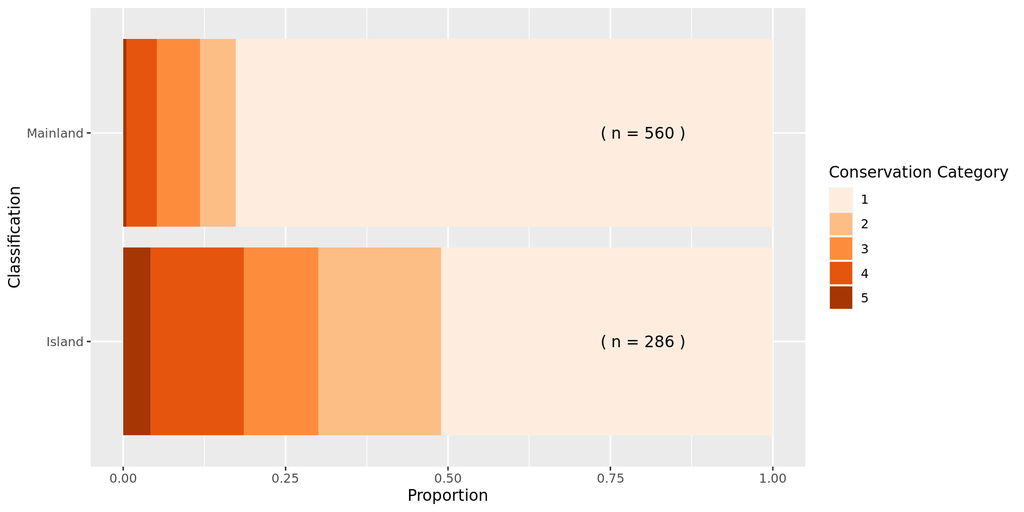

```r
size.df$x = classification
size.df$y=0.8

ggplot(subsettable,aes(x=Island.mainland.classification))+
  geom_bar(aes(fill=factor(Conservation.category.numeric)),position="fill")+
  scale_fill_brewer(palette=7)+
  ylab("Proportion")+
  xlab("Classification")+
  geom_text(data=size.df,aes(label=sizes,y=y,x=x))+
  labs(fill="Conservation Category")+
  coord_flip()
```

## 11.4 Category by elevation

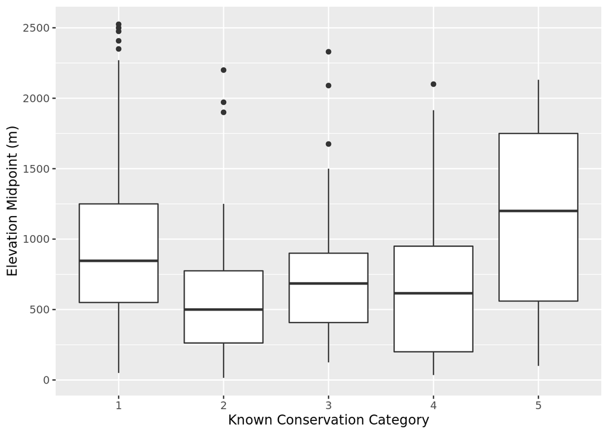

```r
subsettable = with(modelVariables,data.frame(Altitude.mid.m,Conservation.category.numeric))
subsettable=subsettable[complete.cases(subsettable),]
tab = addmargins(table(subsettable))



p=nrow(tab)-1
classification = rownames(tab);classification=classification[1:p]#removes "sum"
sizes = paste( "( n =",tab[1:p,ncol(tab)],")")

size.df = data.frame(
  sizes=sizes,
  x=seq_len(p),
  y=rep(1.5,p)
)



#kable(tab)

ggplot(subsettable,aes(x=Altitude.mid.m,y=factor(Conservation.category.numeric)))+
   geom_boxplot()+xlab("Elevation Midpoint (m)")+ylab("Known Conservation Category")+
  coord_flip()
```

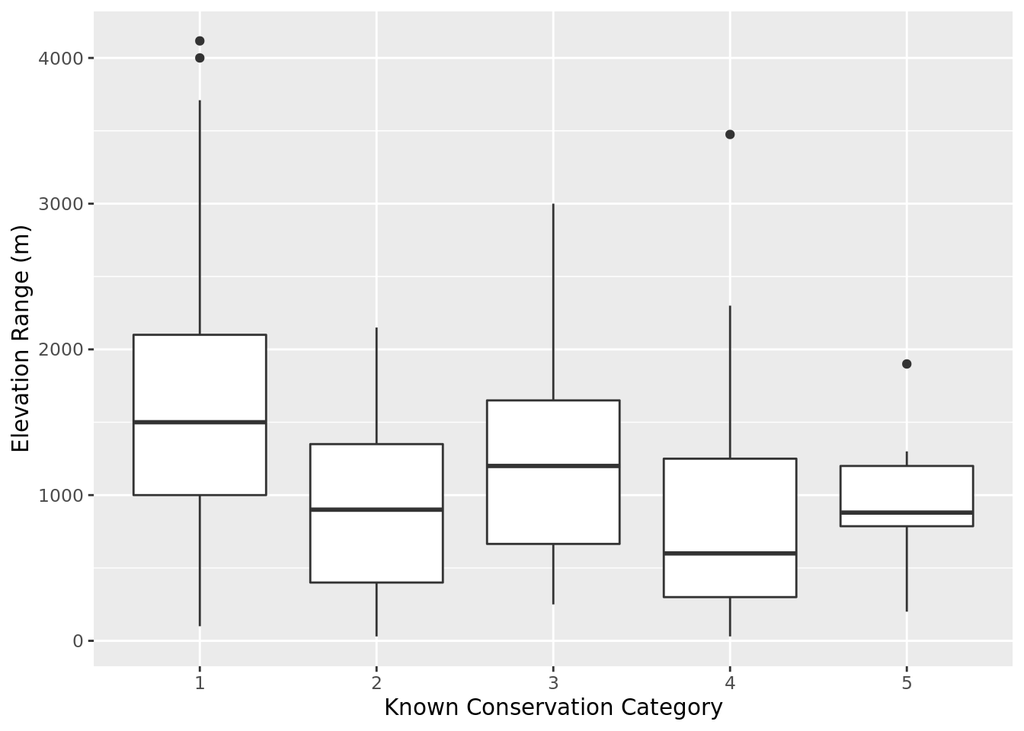

```r
#boxplot(modelVariables$Conservation.category.numeric~modelVariables$Habitats)

subsettable = with(modelVariables,data.frame(Altitude.range.m,Conservation.category.numeric))
subsettable=subsettable[complete.cases(subsettable),]
tab = addmargins(table(subsettable))


p=nrow(tab)-1
classification = rownames(tab);classification=classification[1:p]#removes "sum"
sizes = paste( "( n =",tab[1:p,ncol(tab)],")")

size.df = data.frame(
  sizes=sizes,
  x=seq_len(p),
  y=rep(1.5,p)
)

ggplot(subsettable,aes(x=Altitude.range.m,y=factor(Conservation.category.numeric)))+
   geom_boxplot()+xlab("Elevation Range (m)")+ylab("Known Conservation Category")+
  coord_flip()
```

```r
#boxplot(modelVariables$Conservation.category.numeric~modelVariables$Habitats)
```

## 11.5 Category by Area

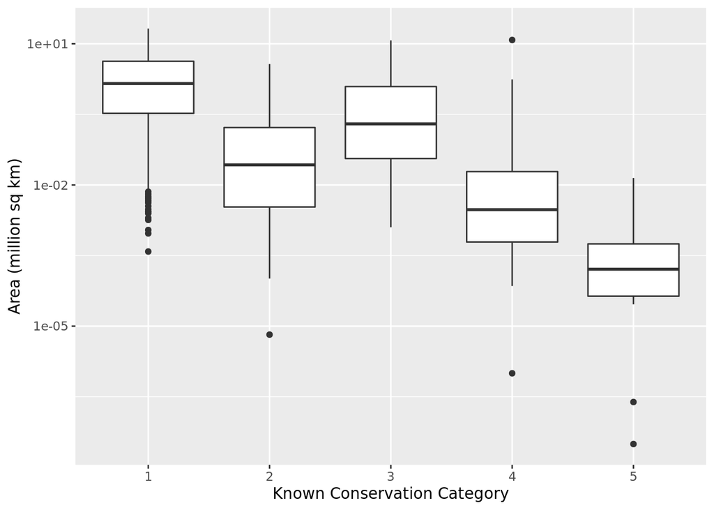

```r
subsettable = with(modelVariables,data.frame(Area.mkm,Conservation.category.numeric))
subsettable=subsettable[complete.cases(subsettable),]
tab = addmargins(table(subsettable))

p=nrow(tab)-1
classification = rownames(tab);classification=classification[1:p]#removes "sum"
sizes = paste( "( n =",tab[1:p,ncol(tab)],")")

size.df = data.frame(
  sizes=sizes,
  x=seq_len(p),
  y=rep(1.5,p)
)

#kable(tab)

ggplot(subsettable,aes(x=Area.mkm,y=factor(Conservation.category.numeric)))+
   geom_boxplot()+xlab("Area (million sq km)")+ylab("Known Conservation Category")+scale_x_log10()+coord_flip()
```

```r
#boxplot(modelVariables$Conservation.category.numeric~modelVariables$Habitats)
```

## 11.6 Category by Max temp

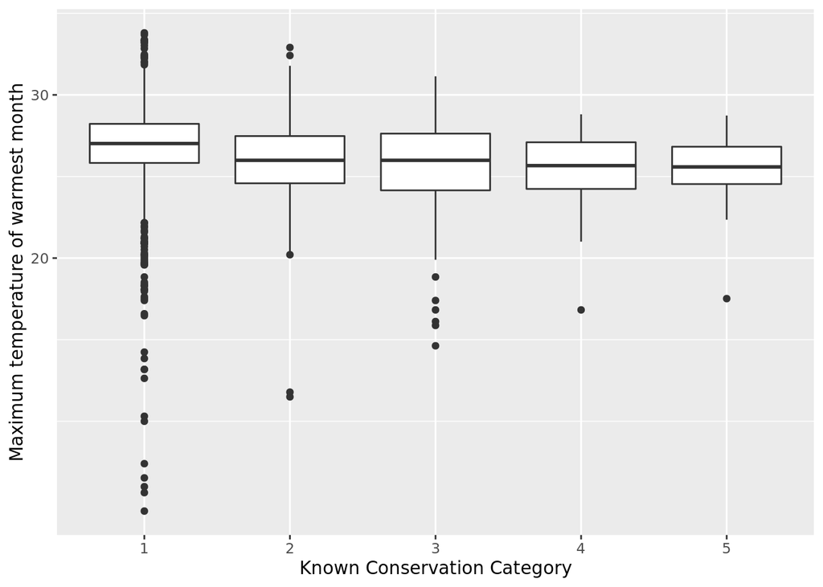

```r
subsettable = with(modelVariables,data.frame(Max.temp.warmest.month,Conservation.category.numeric))
subsettable[,1]=subsettable[,1]/12
subsettable=subsettable[complete.cases(subsettable),]
tab = addmargins(table(subsettable))

p=nrow(tab)-1
classification = rownames(tab);classification=classification[1:p]#removes "sum"
sizes = paste( "( n =",tab[1:p,ncol(tab)],")")

size.df = data.frame(
  sizes=sizes,
  x=seq_len(p),
  y=rep(1.5,p)
)

#kable(tab)

ggplot(subsettable,aes(x=Max.temp.warmest.month,y=factor(Conservation.category.numeric)))+
   geom_boxplot()+xlab("Maximum temperature of warmest month")+ylab("Known Conservation Category")+scale_x_log10()+coord_flip()
```

```r
#boxplot(modelVariables$Conservation.category.numeric~modelVariables$Habitats)
```

## 11.7 Category by Weight

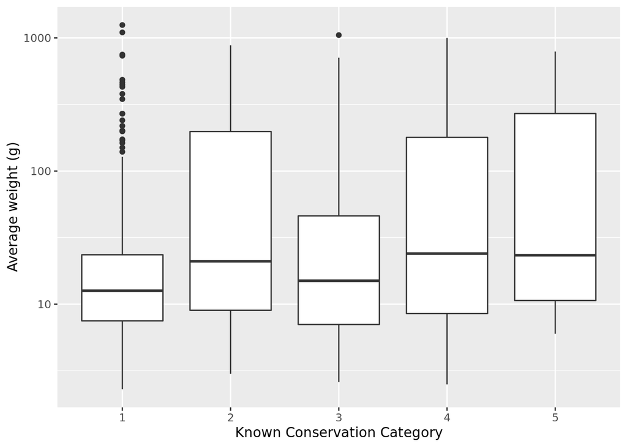

```r
subsettable = with(modelVariables,data.frame(weight.avg.g,Conservation.category.numeric))
subsettable=subsettable[complete.cases(subsettable),]
tab = addmargins(table(subsettable))


p=nrow(tab)-1
classification = rownames(tab);classification=classification[1:p]#removes "sum"
sizes = paste( "( n =",tab[1:p,ncol(tab)],")")

size.df = data.frame(
  sizes=sizes,
  x=seq_len(p),
  y=rep(1.5,p)
)

ggplot(subsettable,aes(x=weight.avg.g,y=factor(Conservation.category.numeric)))+
   geom_boxplot()+xlab("Average weight (g)")+ylab("Known Conservation Category")+
  scale_x_log10()+coord_flip()
```

```r
#boxplot(modelVariables$Conservation.category.numeric~modelVariables$Habitats)
```

# 12 Tables

Tables of the highest fitted conservation statuses

### 12.0.1 By highest median GLS estimates

```r
imputedEstimates[order(imputedEstimates$glsestimate,decreasing=T),]
```

```
##                              glsestimate actual
## Rhinolophus_willardi          2.98866241      4
## Phyllonycteris_aphylla        2.97937605      5
## Rhinolophus_hilli             2.80970659      5
## Pteropus_aldabrensis          2.80760354      4
## Pteralopex_flanneryi          2.68255625      5
## Rousettus_linduensis          2.68024462   <NA>
## Pteropus_melanopogon          2.66154961      4
## Chaerephon_solomonis          2.65949873      4
## Pteropus_voeltzkowi           2.64108001      2
## Pteropus_niger                2.63659000      4
## Plecotus_sacrimontis          2.63022726      1
## Nyctophilus_microdon          2.62701817   <NA>
## Carollia_manu                 2.62143721      1
## Pteropus_livingstonii         2.62066437      5
## Pteronotus_quadridens         2.61282168      1
## Nyctimene_minutus             2.60988582      2
## Falsistrellus_mordax          2.60597753   <NA>
## Hipposideros_demissus         2.57899543      4
## Hipposideros_papua            2.57796739      1
## Rhinolophus_mabuensis         2.57407126      4
## Pteropus_mariannus            2.56557248      4
## Pteropus_conspicillatus       2.56517628      1
## Peropteryx_trinitatis         2.54483166   <NA>
## Dyacopterus_rickarti          2.54314329      4
## Hipposideros_sumbae           2.54272582      1
## Alionycteris_paucidentata     2.53611178      1
## Nycticeius_cubanus            2.53223502      3
## Notopteris_neocaledonica      2.52293441      4
## Chaerephon_bregullae          2.51165773      4
## Pteropus_dasymallus           2.49689791      2
## Hipposideros_calcaratus       2.49168571      1
## Pteropus_griseus              2.49120922   <NA>
## Acerodon_jubatus              2.49090687      4
## Pteropus_rufus                2.48596894      2
## Nycteris_javanica             2.48248370      2
## Pteropus_rodricensis          2.47761716      4
## Emballonura_serii             2.47357261      2
## Nyctiellus_lepidus            2.46821957      1
## Dobsonia_pannietensis         2.46599763      3
```

[output cut: 987 more lines]

```
## Myotis_riparius               0.36950171      1
## Nyctinomops_aurispinosus      0.35559886      1
## Cynomops_planirostris         0.29821567      1
## Lasiurus_blossevillii         0.24086436      1
## Myotis_daubentonii            0.23430894      1
## Vespertilio_murinus           0.21889540      1
## Myotis_nigricans              0.19044112      1
## Eptesicus_fuscus              0.17690036      1
## Molossus_molossus             0.17401377      1
## Rhinolophus_ferrumequinum     0.15808380      1
## Nyctinomops_macrotis          0.12295102      1
## Eptesicus_brasiliensis        0.09737607      1
## Eumops_perotis                0.07854037      1
## Phyllostomus_discolor        -0.07880272      1
## Desmodus_rotundus            -0.21164353      1
```

### 12.0.2 By actual conservation status

```r
imputedEstimates[order(imputedEstimates$actual,decreasing=T),]
```

```
##                              glsestimate actual
## Coleura_seychellensis         2.04148915      5
## Hipposideros_hypophyllus      2.10370078      5
## Hipposideros_lamottei         1.48768069      5
## Eudiscoderma_thongareeae      1.98755103      5
## Phyllonycteris_aphylla        2.97937605      5
## Aproteles_bulmerae            2.08438704      5
## Dobsonia_chapmani             1.98227215      5
## Mirimiri_acrodonta            2.11451450      5
## Pteralopex_flanneryi          2.68255625      5
## Pteralopex_pulchra            2.44817433      5
## Pteropus_aruensis             2.40866743      5
## Pteropus_livingstonii         2.62066437      5
## Rhinolophus_hilli             2.80970659      5
## Myotis_yanbarensis            2.03012567      5
## Nyctophilus_nebulosus         1.98574711      5
## Pharotis_imogene              2.10584030      5
## Emballonura_semicaudata       2.06611240      4
## Saccopteryx_antioquensis      2.29071099      4
## Taphozous_hildegardeae        2.25123344      4
## Hipposideros_coxi             2.23489947      4
## Hipposideros_curtus           1.48838064      4
## Hipposideros_demissus         2.57899543      4
## Hipposideros_turpis           1.94722789      4
## Miniopterus_fuscus            1.96369567      4
## Miniopterus_robustior         2.36744463      4
## Chaerephon_bregullae          2.51165773      4
## Chaerephon_solomonis          2.65949873      4
## Chaerephon_tomensis           1.73352756      4
## Molossops_aequatorianus       1.76852007      4
## Mormopterus_acetabulosus      2.33633371      4
## Tadarida_latouchei            1.83926015      4
## Tomopeas_ravus                1.80721846      4
## Pteronotus_paraguanensis      2.05485942      4
## Chiroderma_improvisum         2.11887509      4
## Leptonycteris_nivalis         1.51556541      4
## Lonchophylla_bokermanni       1.78737402      4
## Lonchophylla_dekeyseri        1.66919980      4
## Acerodon_humilis              2.32059362      4
## Acerodon_jubatus              2.49090687      4
```

[output cut: 987 more lines]

```
## Nyctophilus_microdon          2.62701817   <NA>
## Nyctophilus_shirleyae         1.60042778   <NA>
## Pipistrellus_aero             1.53131228   <NA>
## Pipistrellus_inexspectatus    1.35864652   <NA>
## Pipistrellus_permixtus        1.39377904   <NA>
## Pipistrellus_raceyi           2.04671730   <NA>
## Plecotus_balensis             2.18443227   <NA>
## Plecotus_christii             1.87064969   <NA>
## Rhogeessa_hussoni             1.71978263   <NA>
## Rhogeessa_menchuae            1.04051900   <NA>
## Scotoecus_albofuscus          0.92832891   <NA>
## Scotophilus_borbonicus        2.45948008   <NA>
## Scotophilus_celebensis        1.84895507   <NA>
## Scotophilus_nucella           1.60724278   <NA>
## Tylonycteris_pygmaeus         1.49128815   <NA>
```

# 13 Continuous variables by conservation status

## 13.1 By area

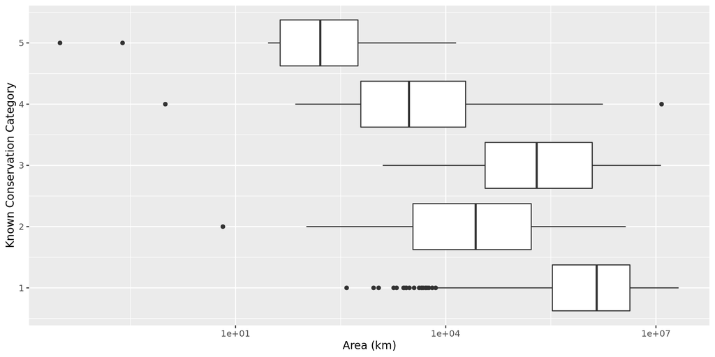

```r
subsettable = with(name.data,data.frame(Area.km,Conservation.category.numeric))
subsettable=subsettable[complete.cases(subsettable),]

ggplot(subsettable,aes(x=Area.km,y=Conservation.category.numeric,group=Conservation.category.numeric))+
  geom_boxplot()+xlab("Area (km)")+ylab("Known Conservation Category")+scale_x_continuous(trans='log10')
```

```r
  # geom_text(data=size.df,aes(label=sizes,y=y,x=x))+
  #coord_flip()
#boxplot(modelVariables$Conservation.category.numeric~modelVariables$Habitats)
```

## 13.2 By temperature

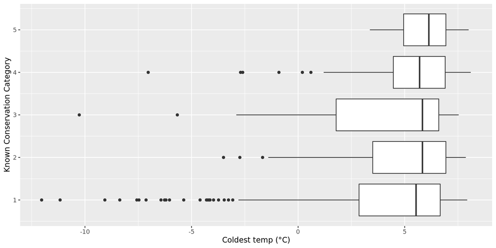

```r
subsettable = with(name.data,data.frame(Min.temp.coldest.month,Conservation.category.numeric))
subsettable=subsettable[complete.cases(subsettable),]
subsettable[,1]=subsettable[,1]/30

ggplot(subsettable,aes(x=Min.temp.coldest.month,y=Conservation.category.numeric,group=Conservation.category.numeric))+
  geom_boxplot()+xlab("Coldest temp (°C)")+ylab("Known Conservation Category")
```

# 14 TypeI vs type II analsyis

In the code below, we try to estimate if a species is high-risk (positive) or low-risk (negative). We define high-risk as being category 4 or 5.

The type I error rate is the proportion of low-risk species being called high risk (accidental flags).

The type II error rate is the proportion of high-risk species being called low-risk (missing stuff).

I think we can approach it this way: decide what type II error rate we think is reasonable, and look to see if the corresponding type I error rate is acceptable..

```r
obtain2x2 = function(k,residuals,fitted){ #k is the threshold
  precisionrecall = mcsapp(1:length(imputedModelsGLS),function(i){

    predictions  = fitted                  #   =yhat
    actualvalues = residuals+predictions   #  y=r+yhat

    predictedrisk = predictions >= k
    actuallyatrisk= actualvalues>=4

    tp = mean( predictedrisk &  actuallyatrisk)
    tn = mean(!predictedrisk & !actuallyatrisk)
    fp = mean( predictedrisk & !actuallyatrisk)
    fn = mean(!predictedrisk &  actuallyatrisk)

    c(tp=tp,tn=tn,fp=fp,fn=fn)
  })
  rowMeans(precisionrecall)
}

geterrors = function(dat){
  dat=as.data.frame(dat)

  tpr = sensitivity = with(dat,tp/(tp+fn))
  tnr = specificity = with(dat,tn/(tn+fp))
  fpr =               with(dat,fp/(fp+tn))

  type1 = fpr
  type2 = with(dat,fn/(tp+fn))
  power = 1-type2

  ord = order(tpr)
#  tpr=tpr[order(tpr)]
#  tnr=tnr[order(tnr)]
  data.frame(type1=type1,type2=type2)
}

phylosig(bat.tree,name.data$Conservation.category.numeric,method="K")
```

```
## [1] "x has no names; assuming x is in the same order as tree$tip.label"
## [1] "some data in x given as 'NA', dropping corresponding species from tree"
```

```
##
## Phylogenetic signal K : 0.0579726
```

```r
phylosig(bat.tree,name.data$Conservation.category.numeric,method="lambda")
```

```
## [1] "x has no names; assuming x is in the same order as tree$tip.label"
## [1] "some data in x given as 'NA', dropping corresponding species from tree"
```

```
##
## Phylogenetic signal lambda : 0.104964
## logL(lambda) : -1273.52
```

```r
thresholds = seq(0,5,.05)

prs = mcsapp(thresholds,
             obtain2x2,
             residuals=imputedGLS.residuals,
             fitted=imputedGLS.fitted) |>
  t() |> as.data.frame()


fitted = imputedGLS.fitted
actual = fitted+imputedGLS.residuals

fitted=fitted[knownSpecies,]
actual=actual[knownSpecies,]


require(pROC)
```

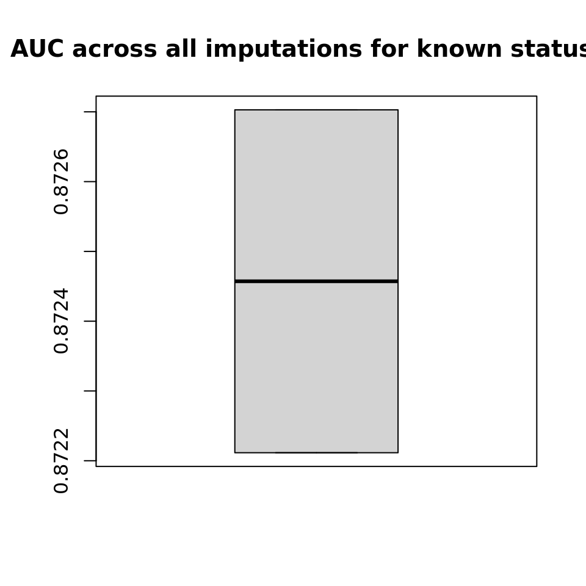

```r
getroc = function(i) roc(actual[,i]>=4,fitted[,i],quiet=T)
getauc = function(roc)roc$auc[1]

rocs = mclapp(1:ncol(actual),getroc)
aucs = mcsapp(rocs,getauc)
boxplot(aucs,main="AUC across all imputations for known statuses",horizontal=F)
```

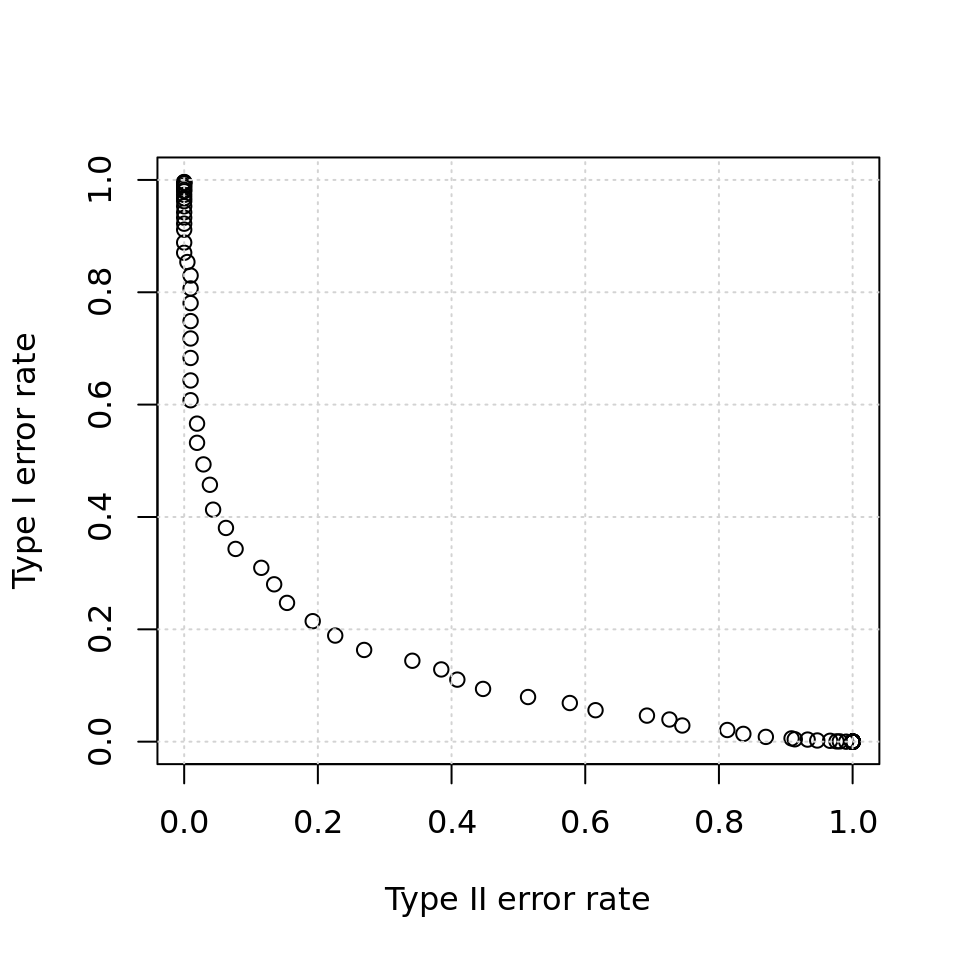

```r
prsvalues = geterrors(prs)


plot(prsvalues$type2,prsvalues$type1,xlim=c(0,1),ylim=c(0,1),xlab="Type II error rate",lty=1,ylab="Type I error rate")
grid()
```

## 14.1 Create an approximate correlation between fitted and actual values (like R^2)

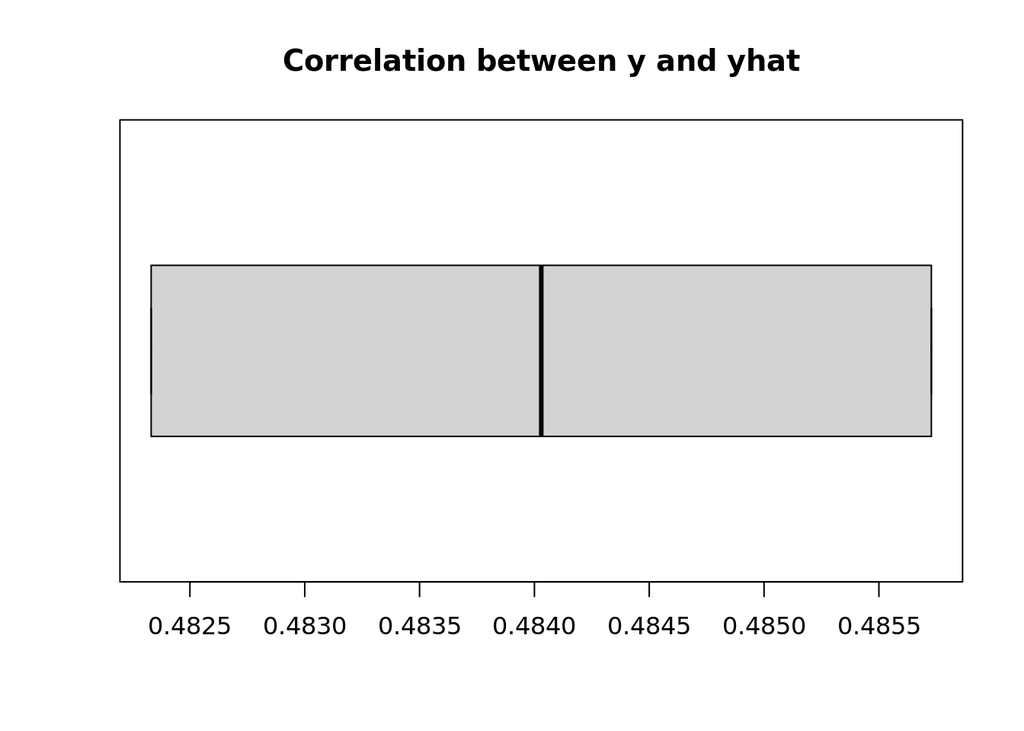

```r
cors = apply(imputedGLS.fitted,2,function(fits)
  cor(fits[knownSpecies],actualStatus[knownSpecies])
  )
boxplot(cors,horizontal=T,main="Correlation between y and yhat")
```

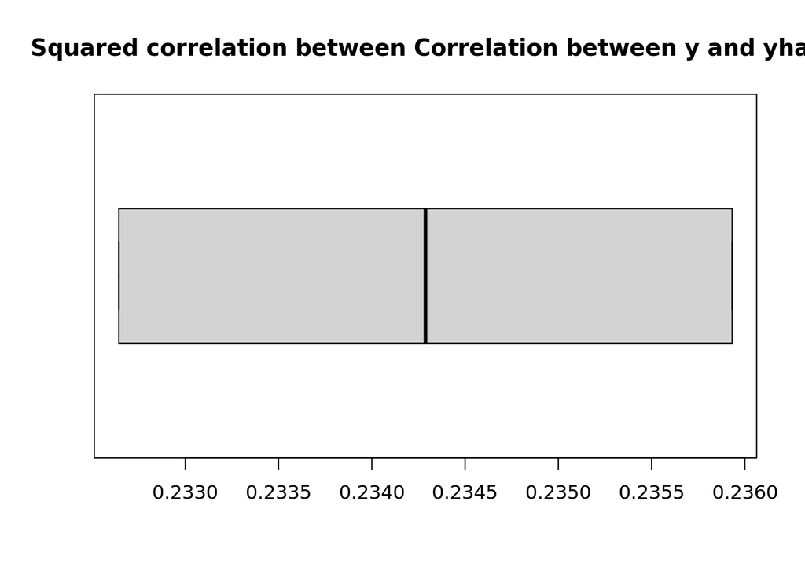

```r
boxplot(cors^2,horizontal=T,main="Squared correlation between Correlation between y and yhat")
```

# 15 Comparison with complete data

```r
completelm = lm(Conservation.category.numeric~ .,
                    data = modelVariables)



yhat = completelm$fitted.values
y    = yhat + completelm$residuals
lmr2all=cor(y,yhat)^2
```

## 15.1 How much each variable explains by itself

```r
modmatrix = modelVariables
  # with(name.data,data.frame(Conservation.category.numeric,
  #                     collapsed.Habitats,
  #                     Simple.Primary.diet,
  #                     weight.avg.g,
  #                     Island.mainland.classification,
  #                     Min.temp.coldest.month,
  #                     Annual.precip.,
  #                     Area.mkm))

r2value=function(i){
  df = modmatrix[,c(1,i)]
  mod = lm(Conservation.category.numeric~.,data=df)
  yhat = mod$fitted.values
  y    = yhat + mod$residuals
  round(cor(y,yhat)^2*100/lmr2all)
}

cols = 2:ncol(modmatrix)
explained = data.frame(names(modmatrix[,cols]),sapply(cols,r2value))
names(explained)=c("Var","Percent")
```

```r
print(explained)
```

```
##                              Var Percent
## 1             collapsed.Habitats      10
## 2                 Altitude.mid.m       7
## 3               Altitude.range.m      32
## 4         Max.temp.warmest.month       9
## 5            Simple.Primary.diet       6
## 6                   weight.avg.g      27
## 7 Island.mainland.classification      37
## 8                 Annual.precip.       3
## 9                       Area.mkm      35
```